# Final

Benjamin Bestmann

2023-06-09

## Q 5

#### a

```r
# Exclude Communist and Region
test_data <- q_5data[, !(names(q_5data) %in% c("Comunist", "Region"))]

# Do PCA on the data now
pca_data <- prcomp(test_data, scale = TRUE)

print(pca_data)
```

```
## Standard deviations (1, .., p=9):
## [1] 2.0016087 1.2786710 1.0620355 0.9770691 0.6810568 0.5702026 0.5211586
## [8] 0.3410160 0.3148204
##
## Rotation (n x k) = (9 x 9):
##                          PC1         PC2         PC3          PC4         PC5
## Red_Meat          -0.3026094 -0.05625165 -0.29757957 -0.646476536  0.32216008
## White_Meat        -0.3105562 -0.23685334  0.62389724  0.036992271 -0.30016494
## Eggs              -0.4266785 -0.03533576  0.18152828 -0.313163873  0.07911048
## Milk              -0.3777273 -0.18458877 -0.38565773  0.003318279 -0.20041361
## Fish              -0.1356499  0.64681970 -0.32127431  0.215955001 -0.29003065
## Cereal             0.4377434 -0.23348508  0.09591750  0.006204117  0.23816783
## Starch            -0.2972477  0.35282564  0.24297503  0.336684733  0.73597332
## Nuts               0.4203344  0.14331056 -0.05438778 -0.330287545  0.15053689
## Fruits_Vegetables  0.1104199  0.53619004  0.40755612 -0.462055746 -0.23351666
##                           PC6         PC7         PC8        PC9
## Red_Meat           0.45986989 -0.15033385 -0.01985770  0.2459995
## White_Meat         0.12100707  0.01966356 -0.02787648  0.5923966
## Eggs              -0.36124872  0.44327151 -0.49120023 -0.3333861
## Milk              -0.61843780 -0.46209500  0.08142193  0.1780841
## Fish               0.13679059  0.10639350 -0.44873197  0.3128262
## Cereal            -0.08075842 -0.40496408 -0.70299504  0.1522596
## Starch            -0.14766670 -0.15275311  0.11453956  0.1218582
## Nuts              -0.44701001  0.40726235  0.18379989  0.5182749
## Fruits_Vegetables -0.11854972 -0.44997782  0.09196337 -0.2029503
```

```r
# Get the proportional variance

variance_proportion <- (pca_data$sdev^2) / sum(pca_data$sdev^2)

# Cumulate it

cumulative <- cumsum(variance_proportion)

# Reporting it

proportion_of_variance <- variance_proportion[1:5]
cumulative_variance <- cumulative[5]

proportion_of_variance
```

```
## [1] 0.4451597 0.1816666 0.1253244 0.1060738 0.0515376
```

```r
cumulative_variance
```

```
## [1] 0.9097621
```

#### b

The first 2 components are the 2 most important components in terms of explaining the variance in the data. They have the highest standard deviations and by looking at the rotation matrix you can see which foods impacted these countries protein consumption. For example in PC1, there is a strong negative correlation with eggs so that means that in countries where the consumption of eggs is lower, there tends to be a higher overall protein consumption from other food groups. Conversely, in countries where the consumption of eggs is higher, the overall protein consumption from other food groups may be relatively lower. So if a country eats more eggs, they tend to mainly get their protein from eggs.

This logic can be applied to show that in PC1, eating more Milk and Eggs meant other foods were not needed as much for protein while Cereal and Nuts led to more consumption of other foods for protein.

This extends to PC2 where it is shown that eating more Cereal and White meat meant other foods were not needed as much for protein while more consumption of Fish and Fruits/Vegetables led to more consumption of other foods for protein.

#### c

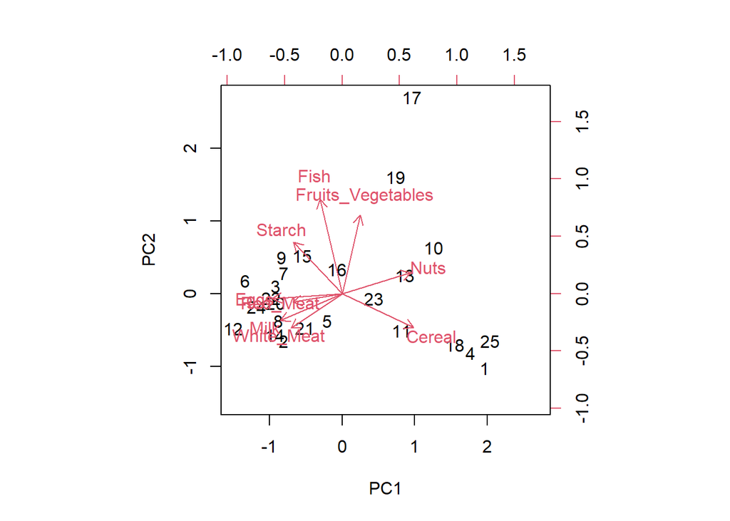

```r
# Make the biplot
biplot(pca_data, choices = c(1, 2), scale = 0.25, expand = 0.8)
```

#### d

```r
north_data <- subset(q_5data, Region %in% c("North"))
central_data <- subset(q_5data, Region %in% c("Center"))
north_data
```

```
##    Comunist Region Red_Meat White_Meat Eggs Milk Fish Cereal Starch Nuts
## 6        No  North     10.6       10.8  3.7 25.0  9.9   21.9    4.8  0.7
## 8        No  North      9.5        4.9  2.7 33.7  5.8   26.3    5.1  1.0
## 15       No  North      9.4        4.7  2.7 23.3  9.7   23.0    4.6  1.6
## 20       No  North      9.9        7.8  3.5 24.7  7.5   19.5    3.7  1.4
##    Fruits_Vegetables
## 6                2.4
## 8                1.4
## 15               2.7
## 20               2.0
```

```r
central_data
```

```
##    Comunist Region Red_Meat White_Meat Eggs Milk Fish Cereal Starch Nuts
## 2        No Center      8.9       14.0  4.3 19.9  2.1   28.0    3.6  1.3
## 3        No Center     13.5        9.3  4.1 17.5  4.5   26.6    5.7  2.1
## 5       Yes Center      9.7       11.4  2.8 12.5  2.0   34.3    5.0  1.1
## 7       Yes Center      8.4       11.6  3.7 11.1  5.4   24.6    6.5  0.8
## 9        No Center     18.0        9.9  3.3 19.5  5.7   28.1    4.8  2.4
## 11      Yes Center      5.3       12.4  2.9  9.7  0.3   40.1    4.0  5.4
## 12       No Center     13.9       10.0  4.7 25.8  2.2   24.0    6.2  1.6
## 14       No Center      9.5       13.6  3.6 23.4  2.5   22.4    4.2  1.8
## 16      Yes Center      6.9       10.2  2.7 19.3  3.0   36.1    5.9  2.0
## 21       No Center     13.1       10.1  3.1 23.8  2.3   25.6    2.8  2.4
## 22       No Center     17.4        5.7  4.7 20.6  4.3   24.3    4.7  3.4
## 23      Yes Center      9.3        4.6  2.1 16.6  3.0   43.6    6.4  3.4
## 24       No Center     11.4       12.5  4.1 18.8  3.4   18.6    5.2  1.5
##    Fruits_Vegetables
## 2                4.3
## 3                4.0
## 5                4.0
## 7                3.6
## 9                6.5
## 11               4.2
## 12               2.9
## 14               3.7
## 16               6.6
## 21               4.9
## 22               3.3
## 23               2.9
## 24               3.8
```

We can see here that in the Northern region, Milk and Cereal tend to be one of the most consumed sources of protein, indicating that other sources are less necessary as determined by PCA1 and PCA2 and their analysis provided above.

## Q 6

The bootstrap is a technique used to estimate the variability of a statistic or make inferences about a population. It involves creating multiple random samples from the original dataset by sampling with replacement. Each sample has the same size as the original dataset but may contain repeated observations.

It is particularly useful for random forest because it helps in creating diverse training sets for each decision tree in the forest. Random forest is a bunch of decision trees, with each tree trained on a different bootstrap sample. By introducing randomness through sampling with replacement, each tree gets to see a slightly different version of the data. This is important because it helps reduce overfitting and improves the overall performance of the model.

In linear regression however, the goal is to find the best-fit line that minimizes the difference between predicted and actual values. The bootstrap resampling doesn’t affect the estimation of the regression coefficients. Linear regression models work better with the specific values in the dataset rather than the different variations produced by bootstrap resampling. Therefore, the bootstrap is not as useful for linear regression compared to random forest.

## Q 2

#### a

```r
# load csv file
library(ISLR2)
q2_data <- Carseats
n <- nrow(q2_data)

x <- model.matrix(Sales ~ ., q2_data)[, -1]
y <- q2_data$Sales

set.seed(123)

# Split the set
train <- sample(1:nrow(x), nrow(x)*0.8)
test <- (-train)
y.test <- y[test]

print('This split is 80% training, 20% testing')
```

```
## [1] "This split is 80% training, 20% testing"
```

#### b

```r
library(glmnet)
```

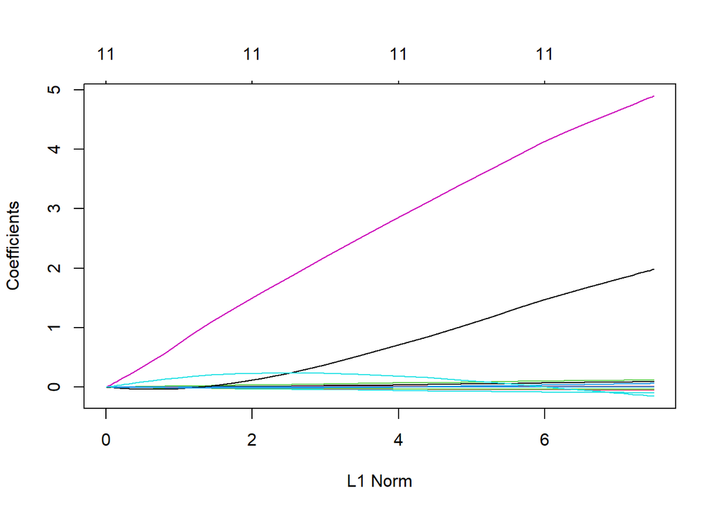

```r
# Perform cross-validated ridge regression
grid <- 10 ^ seq(10, -2, length = 100)
ridge.mod <- glmnet(x[train, ], y[train], alpha = 0, lambda = grid)
plot(ridge.mod)
```

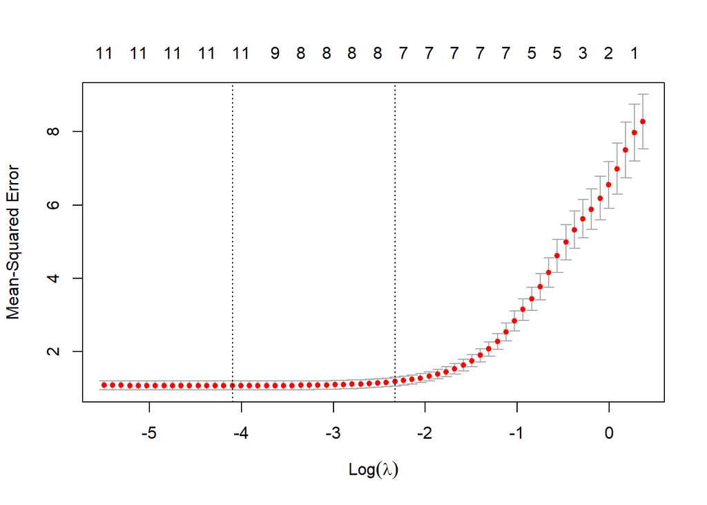

```r
cv.out <- cv.glmnet(x[train, ], y[train], alpha = 1)


# Plot the cross-validated mean squared error (MSE) versus lambda
plot(cv.out)
```

```r
# Choose the best lambda (lowest MSE)
bestlamb <- cv.out$lambda.min

final.model <- glmnet(x[train, ], y[train], alpha = 0, lambda = bestlamb)

# Get the coefficients of the final model
final.coefficients <- coef(final.model)
```

#### c

```r
# Predict the sales values for the validation set
y.pred <- predict(final.model, newx = x[test, ])

# Get RMSE
rmse <- sqrt(mean((y.pred - y.test) ^ 2))

rmse
```

```
## [1] 1.065739
```

#### d

```r
library(randomForest)
# Fit the random forest model on the training data
rf.model <- randomForest(x[train, ], y[train])

# Predict the sales values for the validation set
y.pred <- predict(rf.model, newdata = x[test, ])

rmse <- sqrt(mean((y.pred - y.test) ^ 2))

rmse
```

```
## [1] 1.651978
```

#### e

When comparing the ridge regression and random forest models, marketing teams may have different preferences based on their specific needs.

For instance, if the marketing team prioritizes understanding the factors driving sales and wants to interpret the impact of different variables, they may prefer the ridge regression model. This model provides coefficient estimates for each predictor variable, giving insights into their direction and magnitude of influence on sales. The marketing team can optimize their strategies and make informed decisions using this.